# Analysis: Sex

# Hospital Activity and Patient Demographics

https://www.opendata.nhs.scot/dataset/inpatient-and-daycase-activity/resource/00c00ecc-b533-426e-a433-42d79bdea5d4

# Activity by Board of Treatment, Age and Sex

```r
library(tidyverse)
library(infer)
```

```r
age_sex <- read_csv("../clean_data/age_and_sex.csv")
```

# Sex

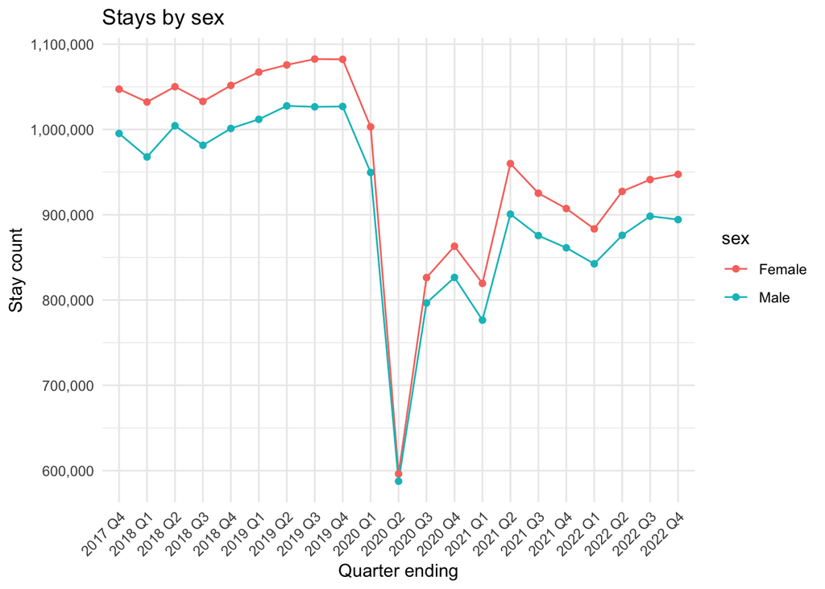

```r
# Number of "stays" (total number of days patients spend in hospital during a continuous inpatient stay)
# Consistently Female > Male by around 50,000 per quarter
age_sex %>%
  select(year_quarter, sex, stays) %>%
  group_by(year_quarter, sex) %>%
  summarise(stays_count = sum(stays)) %>%
  ungroup() %>%
  ggplot(aes(x = year_quarter, y = stays_count, colour = sex, group = sex)) +
  geom_line() +
  geom_point() +
  scale_y_continuous(labels = scales::comma) +
  theme_minimal() +
  theme(axis.text.x = element_text(angle = 45, hjust = 1)) +
  labs(
    title = "Stays by sex",
    x = "Quarter ending",
    y = "Stay count"
  )
```

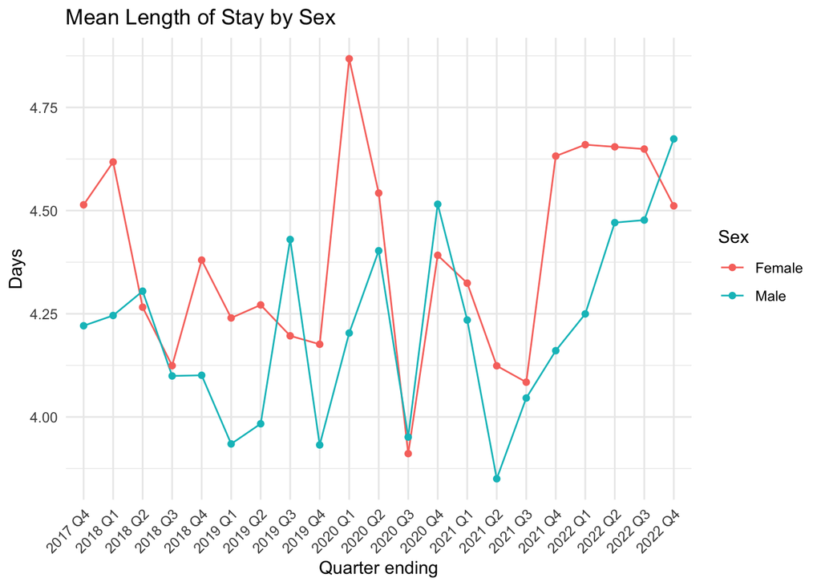

```r
# Mean length of stay
# No clear trend...maybe Female > Male on average
# Range is small
age_sex %>%
  select(year_quarter, sex, average_length_of_stay) %>%
  group_by(year_quarter, sex) %>%
  summarise(mean_stay = mean(average_length_of_stay, na.rm = TRUE)) %>%
  ungroup() %>%
  ggplot(aes(x = year_quarter, y = mean_stay, group = sex, colour = sex)) +
  geom_line() +
  geom_point() +
  scale_colour_discrete(name = "Sex")+
  theme_minimal() +
  theme(axis.text.x = element_text(angle = 45, hjust = 1)) +
  labs(
    title = "Mean Length of Stay by Sex",
    x = "Quarter ending",
    y = "Days"
  )
```

# Question 1: To what extent are the ‘winter crises’ reported by the media real?

```r
age_sex %>%
  group_by(winter) %>%
  summarise(mean_stays = mean(stays, na.rm = TRUE),
            mean_length_of_stay = mean(average_length_of_stay, na.rm = TRUE))
```

| winter | mean_stays | mean_length_of_stay |
| --- | --- | --- |
| FALSE | 300.6329 | 4.240306 |
| TRUE | 308.4099 | 4.352855 |

Doesn’t look like a significant difference.

### HYPOTHESIS TESTING

h0: the number of stays (both sexes total) is not significantly greater in winter quarters relative to non-winter quarters h1: the number of stays is greater in winter quarters

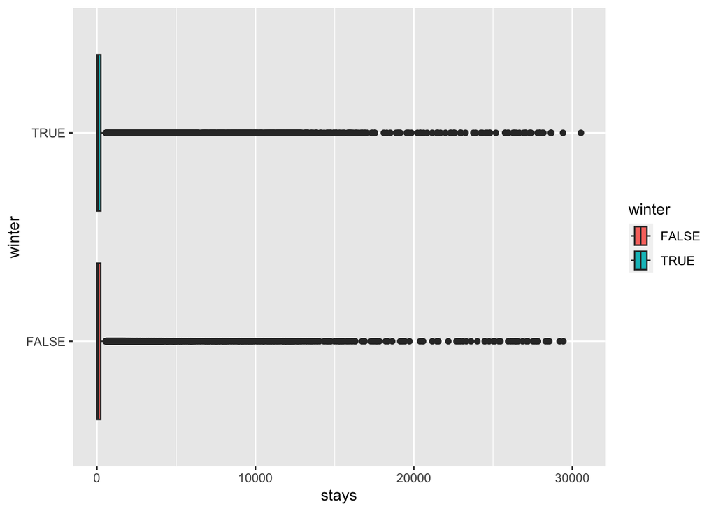

```r
# Boxplot
age_sex %>%
  ggplot(aes(x = stays, y = winter, fill = winter)) +
  geom_boxplot()
```

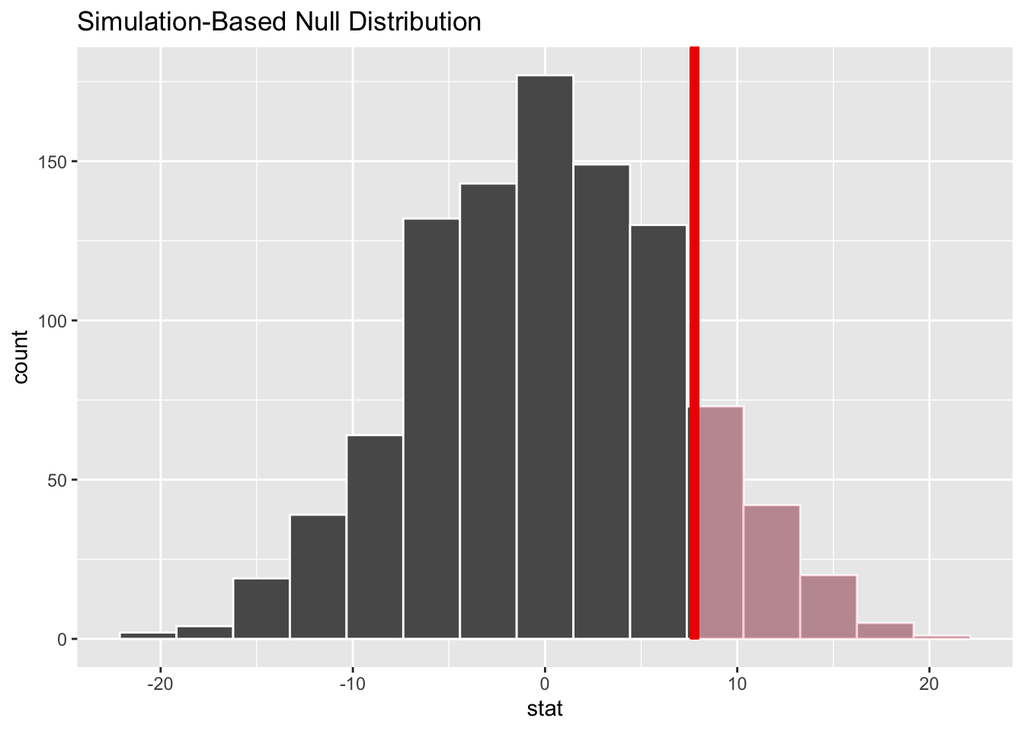

```r
# Set up null distriburtion
null_dist_winter <- age_sex %>%
  specify(stays ~ winter) %>%
  hypothesise(null = "independence") %>%
  generate(reps = 1000, type = "permute") %>%
  calculate(stat = "diff in means", order = c(T, F))

# Calculate the observed stat
obs_stat_winter <- age_sex %>%
  specify(stays ~ winter) %>%
  calculate(stat = "diff in means", order = c(T, F))

# Visualise confidence interval
null_dist_winter %>%
  visualise() +
  shade_p_value(obs_stat = obs_stat_winter, direction = "right")
```

```r
# Find p-value
pvalue_winter <- null_dist_winter %>%
  get_p_value(obs_stat = obs_stat_winter, direction = "right")
pvalue_winter
```

| p_value |
| --- |
| 0.129 |

With a p-value around 0.12, we fail to reject the null hypothesis. The number of hospital stays is, on average, greater in winter, but not significantly so.

# Question 2: How has the Covid-19 pandemic affected provision of acute care in Scotland?

- Demographic: Who is most affected by this issue? (Who should be targeted with efforts?)

## Overall

```r
age_sex %>%
  group_by(post_covid) %>%
  summarise(mean_stays = mean(stays, na.rm = TRUE),
            mean_length_of_stay = mean(average_length_of_stay, na.rm = TRUE))
```

| post_covid | mean_stays | mean_length_of_stay |
| --- | --- | --- |
| FALSE | 331.9849 | 4.224445 |
| TRUE | 283.7950 | 4.357884 |

Drop in the number of stays….significant? Increase in length of stay….significant?

*Hypthesis Test* h0: There is no significant decrease post-covid in the overall number of stays in hospital. h1: There are significantly fewer stays in hospital post-covid.

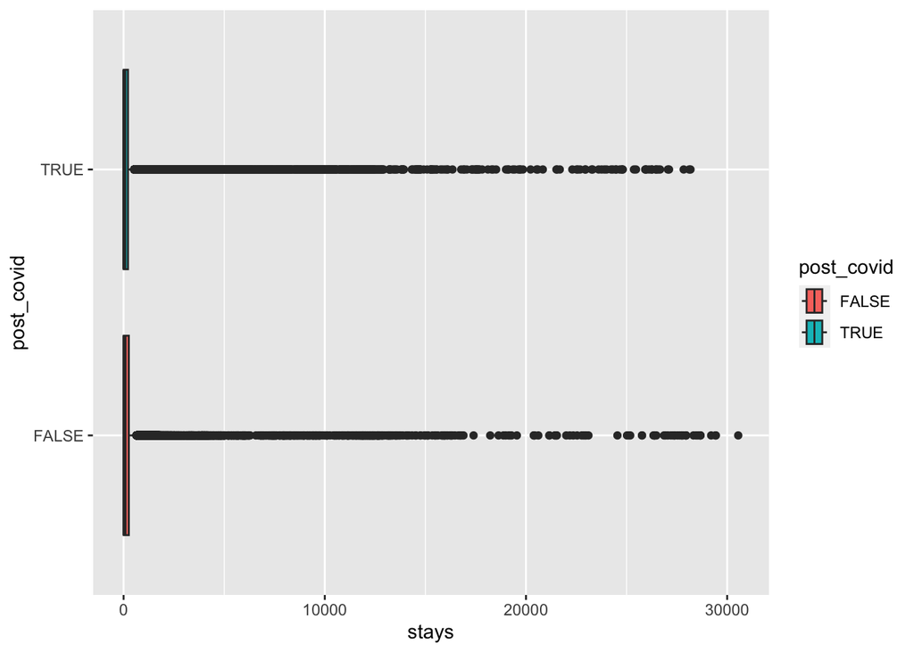

```r
age_sex %>%
  ggplot(aes(x = stays, y = post_covid, fill = post_covid)) +
  geom_boxplot()
```

```r
null_distribution <- age_sex %>%
  specify(response = stays, explanatory = post_covid) %>%
  hypothesize(null = "independence") %>%
  generate(reps = 100, type = "permute") %>%
  calculate(stat = "diff in means", order = c(TRUE, FALSE))

observed_stat <- age_sex %>%
  specify(stays ~ post_covid) %>%
  calculate(stat= "diff in means", order = c(TRUE, FALSE))

observed_stat
```

| stat |
| --- |
| -48.18991 |

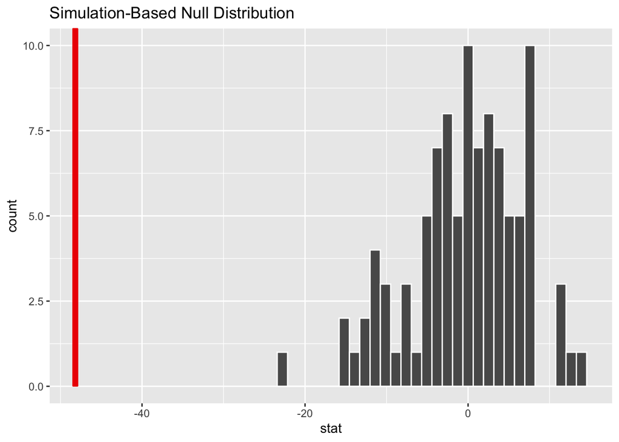

```r
null_distribution %>%
  visualise(bins = 30) +
  shade_p_value(obs_stat = observed_stat, direction = "left")
```

```r
null_distribution %>%
  get_p_value(obs_stat = observed_stat, direction = "left")
```

| p_value |
| --- |
| 0 |

*Reject null hypothesis.* *There are significantly fewer stays in hospital post-covid.* Why?

## Post-covid changes of different sexes

```r
age_sex %>%
  group_by(sex, post_covid) %>%
  summarise(mean_stays = mean(stays, na.rm = TRUE),
            mean_length_of_stay = mean(average_length_of_stay, na.rm = TRUE))
```

[output not shown]

| sex | post_covid | mean_stays | mean_length_of_stay |
| --- | --- | --- | --- |
| Female | FALSE | 340.1441 | 4.309478 |
| Female | TRUE | 290.5540 | 4.447226 |
| Male | FALSE | 323.8065 | 4.139345 |
| Male | TRUE | 277.0218 | 4.268788 |

Post-covid, the number of stays in both groups has decreased by a lot. Has one sex been affected more than the other? Post-covid, the length of stays in both groups has increased by a small amount. Has one sex been affected more than the other?

```r
# Wrangling data set
male_stays <- age_sex %>%
  filter(sex == "Male") %>%
  rename(male_stays = stays,
         average_length_of_male_stay = average_length_of_stay) %>%
  mutate(id = str_c(year_quarter, hb, location, admission_type, age)) %>%
  select(id, male_stays, average_length_of_male_stay, winter, post_covid)

female_stays <- age_sex %>%
  filter(sex == "Female") %>%
  rename(
    female_stays = stays,
    average_length_of_female_stay = average_length_of_stay
  ) %>%
  mutate(id = str_c(year_quarter, hb, location, admission_type, age)) %>%
  select(id, female_stays, average_length_of_female_stay, winter, post_covid)

age_sex_stay_deltas <- full_join(male_stays, female_stays, by = "id") %>%
  mutate(
    female_stays = case_when(female_stays > 0 ~ female_stays,
      .default = 0
    ),
    average_length_of_female_stay =
      case_when(average_length_of_female_stay > 0 ~ average_length_of_female_stay,
        .default = 0
      ),
    male_stays = case_when(male_stays > 0 ~ male_stays,
      .default = 0
    ),
    average_length_of_male_stay =
      case_when(average_length_of_male_stay > 0 ~ average_length_of_male_stay,
        .default = 0
      )
  ) %>%
  rename(
    winter = winter.x,
    post_covid = post_covid.x
  ) %>%
  mutate(winter = case_when(winter == TRUE ~ TRUE,
    winter == FALSE ~ FALSE,
    .default = winter.y
  )) %>%
  mutate(post_covid = case_when(post_covid == TRUE ~ TRUE,
    post_covid == FALSE ~ FALSE,
    .default = post_covid.y
  )) %>%
  mutate(
    more_female_stays = female_stays - male_stays,
    females_stay_longer = average_length_of_female_stay - average_length_of_male_stay
  ) %>%
  select(more_female_stays, females_stay_longer, winter, post_covid)
```

### Number of hospital stays by sex pre/post covid

Hypothesis test: h0: There is no significant change post-covid in the difference between the number of male and female stays in hospital. h1: There is a significant change post-covid in the difference between the number of male and female stays in hospital.

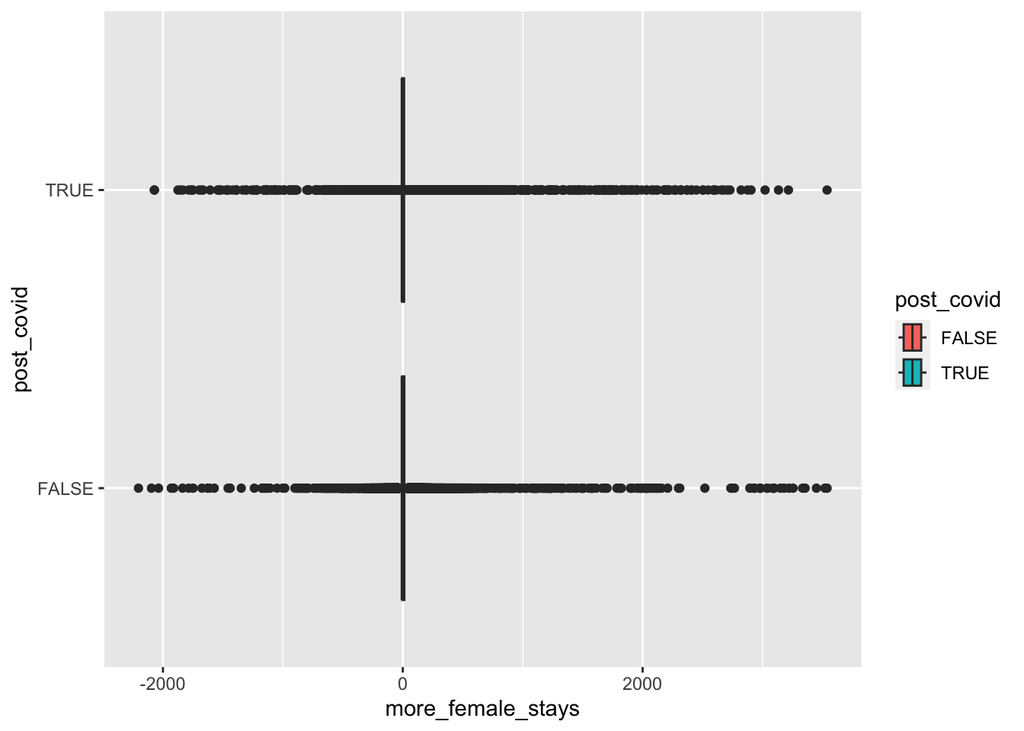

```r
age_sex_stay_deltas %>%
  ggplot(aes(x = more_female_stays, y = post_covid, fill = post_covid)) +
  geom_boxplot()
```

```r
null_distribution <- age_sex_stay_deltas %>%
  specify(response = more_female_stays, explanatory = post_covid) %>%
  hypothesize(null = "independence") %>%
  generate(reps = 1000, type = "permute") %>%
  calculate(stat = "diff in means", order = c(TRUE, FALSE))

observed_stat <- age_sex_stay_deltas %>%
  specify(more_female_stays ~ post_covid) %>%
  calculate(stat= "diff in means", order = c(TRUE, FALSE))

observed_stat
```

| stat |
| --- |
| -2.951236 |

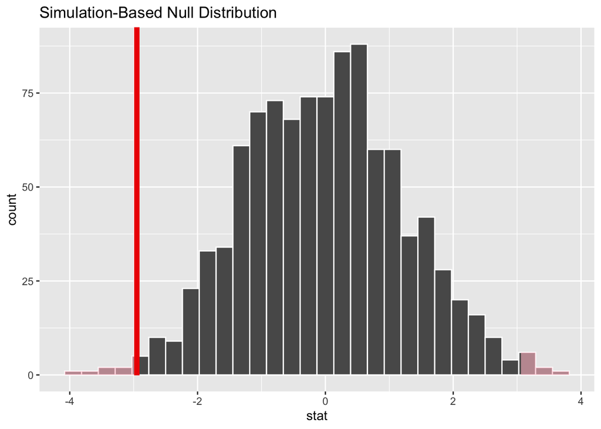

```r
null_distribution %>%
  visualise(bins = 30) +
  shade_p_value(obs_stat = observed_stat, direction = "both")
```

```r
null_distribution %>%
  get_p_value(obs_stat = observed_stat, direction = "both")
```

| p_value |
| --- |
| 0.012 |

### Length of hospital stays by sex pre/post covid

Hypothesis test 2: h0: There is no significant change post-covid in the difference between the length of stays of men and women staying in hospital. h1: There is a significant change post-covid in the difference between the length of stays of men and women staying in hospital.

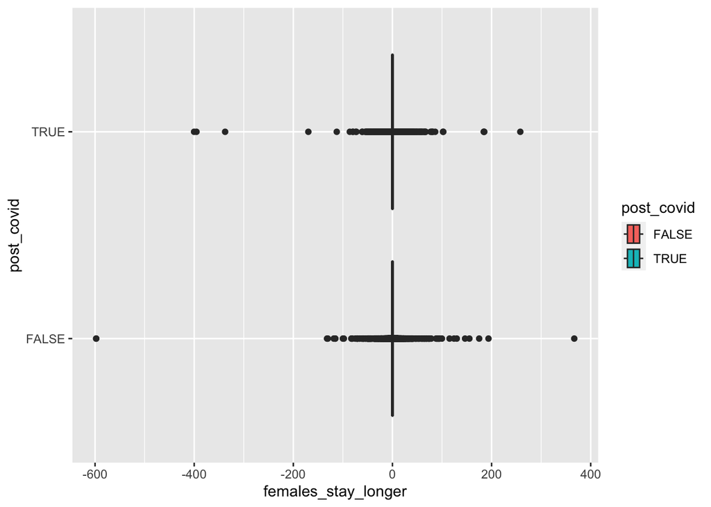

```r
age_sex_stay_deltas %>%
  ggplot(aes(x = females_stay_longer, y = post_covid, fill = post_covid)) +
  geom_boxplot()
```

```r
null_distribution <- age_sex_stay_deltas %>%
  specify(response = females_stay_longer, explanatory = post_covid) %>%
  hypothesize(null = "independence") %>%
  generate(reps = 1000, type = "permute") %>%
  calculate(stat = "diff in means", order = c(TRUE, FALSE))

observed_stat <- age_sex_stay_deltas %>%
  specify(females_stay_longer ~ post_covid) %>%
  calculate(stat= "diff in means", order = c(TRUE, FALSE))

observed_stat
```

| stat |
| --- |
| -0.007542573 |

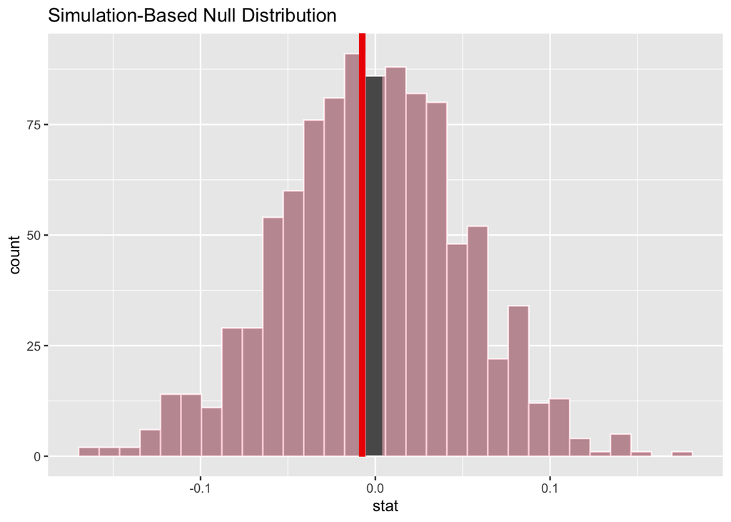

```r
null_distribution %>%
  visualise(bins = 30) +
  shade_p_value(obs_stat = observed_stat, direction = "both")
```

```r
null_distribution %>%
  get_p_value(obs_stat = observed_stat, direction = "both")
```

| p_value |
| --- |
| 0.914 |

*Fail to reject null hyposthesis* *There is no significant change post-covid in the difference between the length of stays of men and women staying in hospital.*